# Risk Factor Analysis

## Outcome Variable

**Outcome Variable:** wasted

## Predictor Variables

**Intervention Variable:** sex

**Adjustment Set:**

unadjusted

## Stratifying Variables

The analysis was stratified on these variable(s):

- agecat
- studyid
- country

## Data Summary

| agecat | studyid | country | sex | wasted | n_cell | n |
| --- | --- | --- | --- | --- | --- | --- |
| Birth | ki0047075b-MAL-ED | BANGLADESH | Female | 0 | 87 | 215 |
| Birth | ki0047075b-MAL-ED | BANGLADESH | Female | 1 | 19 | 215 |
| Birth | ki0047075b-MAL-ED | BANGLADESH | Male | 0 | 92 | 215 |
| Birth | ki0047075b-MAL-ED | BANGLADESH | Male | 1 | 17 | 215 |
| Birth | ki0047075b-MAL-ED | BRAZIL | Female | 0 | 30 | 62 |
| Birth | ki0047075b-MAL-ED | BRAZIL | Female | 1 | 1 | 62 |
| Birth | ki0047075b-MAL-ED | BRAZIL | Male | 0 | 30 | 62 |
| Birth | ki0047075b-MAL-ED | BRAZIL | Male | 1 | 1 | 62 |
| Birth | ki0047075b-MAL-ED | INDIA | Female | 0 | 19 | 45 |
| Birth | ki0047075b-MAL-ED | INDIA | Female | 1 | 3 | 45 |
| Birth | ki0047075b-MAL-ED | INDIA | Male | 0 | 21 | 45 |
| Birth | ki0047075b-MAL-ED | INDIA | Male | 1 | 2 | 45 |
| Birth | ki0047075b-MAL-ED | NEPAL | Female | 0 | 14 | 26 |
| Birth | ki0047075b-MAL-ED | NEPAL | Female | 1 | 2 | 26 |
| Birth | ki0047075b-MAL-ED | NEPAL | Male | 0 | 10 | 26 |
| Birth | ki0047075b-MAL-ED | NEPAL | Male | 1 | 0 | 26 |
| Birth | ki0047075b-MAL-ED | PERU | Female | 0 | 111 | 228 |
| Birth | ki0047075b-MAL-ED | PERU | Female | 1 | 1 | 228 |
| Birth | ki0047075b-MAL-ED | PERU | Male | 0 | 112 | 228 |
| Birth | ki0047075b-MAL-ED | PERU | Male | 1 | 4 | 228 |
| Birth | ki0047075b-MAL-ED | SOUTH AFRICA | Female | 0 | 50 | 120 |
| Birth | ki0047075b-MAL-ED | SOUTH AFRICA | Female | 1 | 6 | 120 |
| Birth | ki0047075b-MAL-ED | SOUTH AFRICA | Male | 0 | 58 | 120 |
| Birth | ki0047075b-MAL-ED | SOUTH AFRICA | Male | 1 | 6 | 120 |
| Birth | ki0047075b-MAL-ED | TANZANIA, UNITED REPUBLIC OF | Female | 0 | 62 | 115 |
| Birth | ki0047075b-MAL-ED | TANZANIA, UNITED REPUBLIC OF | Female | 1 | 1 | 115 |
| Birth | ki0047075b-MAL-ED | TANZANIA, UNITED REPUBLIC OF | Male | 0 | 52 | 115 |
| Birth | ki0047075b-MAL-ED | TANZANIA, UNITED REPUBLIC OF | Male | 1 | 0 | 115 |
| Birth | ki1000108-CMC-V-BCS-2002 | INDIA | Female | 0 | 38 | 86 |
| Birth | ki1000108-CMC-V-BCS-2002 | INDIA | Female | 1 | 5 | 86 |

[output cut: 298 more lines]

The following strata were considered:

- agecat: 24 months, studyid: ki0047075b-MAL-ED, country: BANGLADESH
- agecat: 24 months, studyid: ki0047075b-MAL-ED, country: BRAZIL
- agecat: 24 months, studyid: ki0047075b-MAL-ED, country: INDIA
- agecat: 24 months, studyid: ki0047075b-MAL-ED, country: NEPAL
- agecat: 24 months, studyid: ki0047075b-MAL-ED, country: PERU
- agecat: 24 months, studyid: ki0047075b-MAL-ED, country: SOUTH AFRICA
- agecat: 24 months, studyid: ki0047075b-MAL-ED, country: TANZANIA, UNITED REPUBLIC OF
- agecat: 24 months, studyid: ki1000108-CMC-V-BCS-2002, country: INDIA
- agecat: 24 months, studyid: ki1000108-IRC, country: INDIA
- agecat: 24 months, studyid: ki1000109-EE, country: PAKISTAN
- agecat: 24 months, studyid: ki1017093-NIH-Birth, country: BANGLADESH
- agecat: 24 months, studyid: ki1017093b-PROVIDE, country: BANGLADESH
- agecat: 24 months, studyid: ki1017093c-NIH-Crypto, country: BANGLADESH
- agecat: 24 months, studyid: ki1066203-TanzaniaChild2, country: TANZANIA, UNITED REPUBLIC OF
- agecat: 24 months, studyid: ki1101329-Keneba, country: GAMBIA
- agecat: 24 months, studyid: ki1113344-GMS-Nepal, country: NEPAL
- agecat: 24 months, studyid: ki1114097-CMIN, country: BANGLADESH
- agecat: 24 months, studyid: ki1114097-CONTENT, country: PERU
- agecat: 24 months, studyid: ki1119695-PROBIT, country: BELARUS
- agecat: 24 months, studyid: ki1126311-ZVITAMBO, country: ZIMBABWE
- agecat: 24 months, studyid: ki1135781-COHORTS, country: GUATEMALA
- agecat: 24 months, studyid: ki1135781-COHORTS, country: INDIA
- agecat: 24 months, studyid: ki1135781-COHORTS, country: PHILIPPINES
- agecat: 24 months, studyid: ki1148112-LCNI-5, country: MALAWI
- agecat: 24 months, studyid: kiGH5241-JiVitA-3, country: BANGLADESH
- agecat: 24 months, studyid: kiGH5241-JiVitA-4, country: BANGLADESH
- agecat: 6 months, studyid: ki0047075b-MAL-ED, country: BANGLADESH
- agecat: 6 months, studyid: ki0047075b-MAL-ED, country: BRAZIL
- agecat: 6 months, studyid: ki0047075b-MAL-ED, country: INDIA
- agecat: 6 months, studyid: ki0047075b-MAL-ED, country: NEPAL
- agecat: 6 months, studyid: ki0047075b-MAL-ED, country: PERU
- agecat: 6 months, studyid: ki0047075b-MAL-ED, country: SOUTH AFRICA
- agecat: 6 months, studyid: ki0047075b-MAL-ED, country: TANZANIA, UNITED REPUBLIC OF
- agecat: 6 months, studyid: ki1000108-CMC-V-BCS-2002, country: INDIA
- agecat: 6 months, studyid: ki1000108-IRC, country: INDIA
- agecat: 6 months, studyid: ki1000109-EE, country: PAKISTAN
- agecat: 6 months, studyid: ki1000109-ResPak, country: PAKISTAN
- agecat: 6 months, studyid: ki1000304b-SAS-CompFeed, country: INDIA
- agecat: 6 months, studyid: ki1000304b-SAS-FoodSuppl, country: INDIA
- agecat: 6 months, studyid: ki1017093-NIH-Birth, country: BANGLADESH
- agecat: 6 months, studyid: ki1017093b-PROVIDE, country: BANGLADESH
- agecat: 6 months, studyid: ki1017093c-NIH-Crypto, country: BANGLADESH
- agecat: 6 months, studyid: ki1066203-TanzaniaChild2, country: TANZANIA, UNITED REPUBLIC OF
- agecat: 6 months, studyid: ki1101329-Keneba, country: GAMBIA
- agecat: 6 months, studyid: ki1112895-Guatemala BSC, country: GUATEMALA
- agecat: 6 months, studyid: ki1113344-GMS-Nepal, country: NEPAL
- agecat: 6 months, studyid: ki1114097-CMIN, country: BANGLADESH
- agecat: 6 months, studyid: ki1114097-CONTENT, country: PERU
- agecat: 6 months, studyid: ki1119695-PROBIT, country: BELARUS
- agecat: 6 months, studyid: ki1126311-ZVITAMBO, country: ZIMBABWE
- agecat: 6 months, studyid: ki1135781-COHORTS, country: GUATEMALA
- agecat: 6 months, studyid: ki1135781-COHORTS, country: INDIA
- agecat: 6 months, studyid: ki1135781-COHORTS, country: PHILIPPINES
- agecat: 6 months, studyid: ki1148112-LCNI-5, country: MALAWI
- agecat: 6 months, studyid: kiGH5241-JiVitA-3, country: BANGLADESH
- agecat: 6 months, studyid: kiGH5241-JiVitA-4, country: BANGLADESH
- agecat: Birth, studyid: ki0047075b-MAL-ED, country: BANGLADESH
- agecat: Birth, studyid: ki0047075b-MAL-ED, country: BRAZIL
- agecat: Birth, studyid: ki0047075b-MAL-ED, country: INDIA
- agecat: Birth, studyid: ki0047075b-MAL-ED, country: NEPAL
- agecat: Birth, studyid: ki0047075b-MAL-ED, country: PERU
- agecat: Birth, studyid: ki0047075b-MAL-ED, country: SOUTH AFRICA
- agecat: Birth, studyid: ki0047075b-MAL-ED, country: TANZANIA, UNITED REPUBLIC OF
- agecat: Birth, studyid: ki1000108-CMC-V-BCS-2002, country: INDIA
- agecat: Birth, studyid: ki1000108-IRC, country: INDIA
- agecat: Birth, studyid: ki1000109-EE, country: PAKISTAN
- agecat: Birth, studyid: ki1000109-ResPak, country: PAKISTAN
- agecat: Birth, studyid: ki1000304b-SAS-CompFeed, country: INDIA
- agecat: Birth, studyid: ki1017093-NIH-Birth, country: BANGLADESH
- agecat: Birth, studyid: ki1017093b-PROVIDE, country: BANGLADESH
- agecat: Birth, studyid: ki1017093c-NIH-Crypto, country: BANGLADESH
- agecat: Birth, studyid: ki1101329-Keneba, country: GAMBIA
- agecat: Birth, studyid: ki1113344-GMS-Nepal, country: NEPAL
- agecat: Birth, studyid: ki1114097-CMIN, country: BANGLADESH
- agecat: Birth, studyid: ki1114097-CONTENT, country: PERU
- agecat: Birth, studyid: ki1119695-PROBIT, country: BELARUS
- agecat: Birth, studyid: ki1126311-ZVITAMBO, country: ZIMBABWE
- agecat: Birth, studyid: ki1135781-COHORTS, country: GUATEMALA
- agecat: Birth, studyid: ki1135781-COHORTS, country: INDIA
- agecat: Birth, studyid: ki1135781-COHORTS, country: PHILIPPINES
- agecat: Birth, studyid: kiGH5241-JiVitA-3, country: BANGLADESH
- agecat: Birth, studyid: kiGH5241-JiVitA-4, country: BANGLADESH

### Dropped Strata

Some strata were dropped due to rare outcomes:

- agecat: Birth, studyid: ki0047075b-MAL-ED, country: BRAZIL
- agecat: Birth, studyid: ki0047075b-MAL-ED, country: INDIA
- agecat: Birth, studyid: ki0047075b-MAL-ED, country: NEPAL
- agecat: Birth, studyid: ki0047075b-MAL-ED, country: PERU
- agecat: Birth, studyid: ki0047075b-MAL-ED, country: TANZANIA, UNITED REPUBLIC OF
- agecat: Birth, studyid: ki1000109-ResPak, country: PAKISTAN
- agecat: Birth, studyid: ki1114097-CMIN, country: BANGLADESH
- agecat: Birth, studyid: ki1114097-CONTENT, country: PERU
- agecat: 6 months, studyid: ki0047075b-MAL-ED, country: BANGLADESH
- agecat: 6 months, studyid: ki0047075b-MAL-ED, country: BRAZIL
- agecat: 6 months, studyid: ki0047075b-MAL-ED, country: NEPAL
- agecat: 6 months, studyid: ki0047075b-MAL-ED, country: PERU
- agecat: 6 months, studyid: ki0047075b-MAL-ED, country: SOUTH AFRICA
- agecat: 6 months, studyid: ki0047075b-MAL-ED, country: TANZANIA, UNITED REPUBLIC OF
- agecat: 6 months, studyid: ki1112895-Guatemala BSC, country: GUATEMALA
- agecat: 6 months, studyid: ki1114097-CONTENT, country: PERU
- agecat: 24 months, studyid: ki0047075b-MAL-ED, country: BRAZIL
- agecat: 24 months, studyid: ki0047075b-MAL-ED, country: NEPAL
- agecat: 24 months, studyid: ki0047075b-MAL-ED, country: PERU
- agecat: 24 months, studyid: ki0047075b-MAL-ED, country: SOUTH AFRICA
- agecat: 24 months, studyid: ki0047075b-MAL-ED, country: TANZANIA, UNITED REPUBLIC OF
- agecat: 24 months, studyid: ki1066203-TanzaniaChild2, country: TANZANIA, UNITED REPUBLIC OF
- agecat: 24 months, studyid: ki1114097-CONTENT, country: PERU
- agecat: 24 months, studyid: ki1148112-LCNI-5, country: MALAWI

## Methods Detail

We’re interested in the causal parameters $E[Y_a]$ for all values of $a \in \mathcal{A}$. These parameters represent the mean outcome if, possibly contrary to fact, we intervened to set all units to have $A=a$. Under the randomization and positivity assumptions, these are identified by the statistical parameters $\psi_a=E_W[E_{Y|A,W}(Y|A=a,W)]$. In addition, we’re interested in the mean of $Y$, $E[Y]$ under no intervention (the observed mean). We will estimate these parameters by using SuperLearner to fit the relevant likelihood factors – $E_{Y|A,W}(Y|A=a,W)$ and $p(A=a|W)$, and then updating our likelihood fit using a joint TMLE.

For unadjusted analyses ($W=\{\}$), initial likelihoods were estimated using Lrnr_glm to estimate the simple $E(Y|A)$ and Lrnr_mean to estimate $p(A)$. For adjusted analyses, a small library containing Lrnr_glmnet, Lrnr_xgboost, and Lrnr_mean was used.

Having estimated these parameters, we will then use the delta method to estimate relative risks and attributable risks relative to a prespecified baseline level of $A$.

# Results Detail

## Results Plots

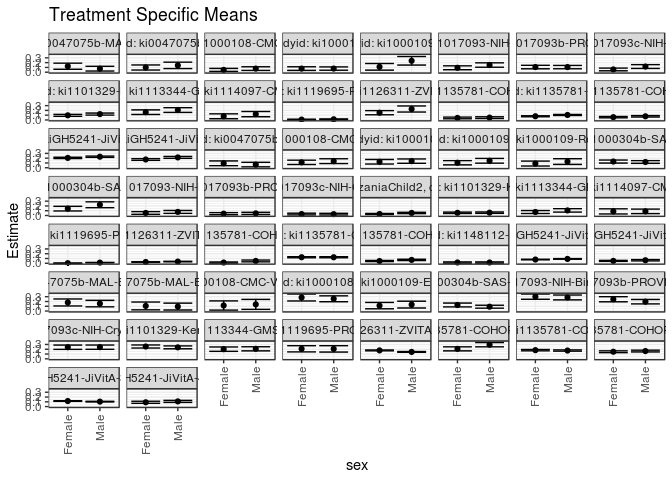

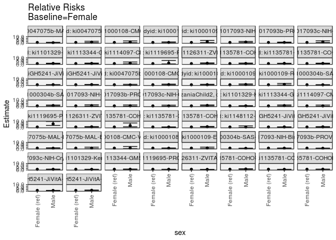

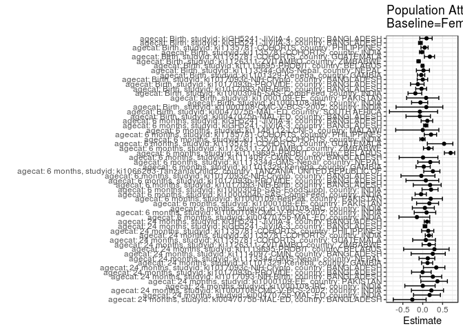

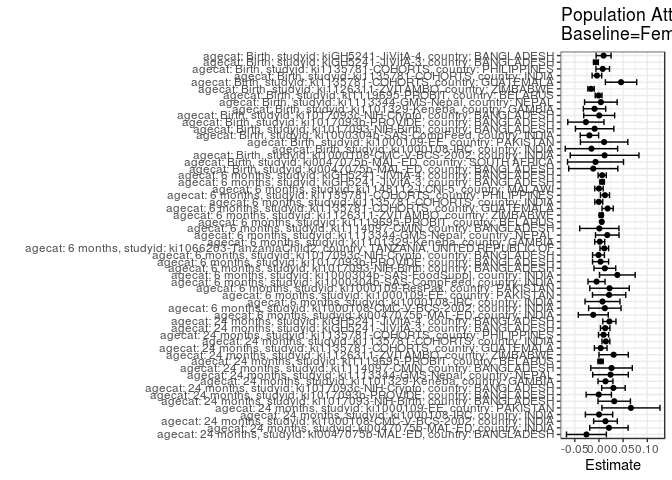

## Results Table

### Parameter: TSM

| agecat | studyid | country | intervention_level | baseline_level | estimate | ci_lower | ci_upper |
| --- | --- | --- | --- | --- | --- | --- | --- |
| Birth | ki0047075b-MAL-ED | BANGLADESH | Female | NA | 0.1792453 | 0.1060576 | 0.2524330 |
| Birth | ki0047075b-MAL-ED | BANGLADESH | Male | NA | 0.1559633 | 0.0876919 | 0.2242347 |
| Birth | ki0047075b-MAL-ED | SOUTH AFRICA | Female | NA | 0.1071429 | 0.0257954 | 0.1884903 |
| Birth | ki0047075b-MAL-ED | SOUTH AFRICA | Male | NA | 0.0937500 | 0.0220391 | 0.1654609 |
| Birth | ki1000108-CMC-V-BCS-2002 | INDIA | Female | NA | 0.1162791 | 0.0199046 | 0.2126535 |
| Birth | ki1000108-CMC-V-BCS-2002 | INDIA | Male | NA | 0.1395349 | 0.0353603 | 0.2437094 |
| Birth | ki1000108-IRC | INDIA | Female | NA | 0.2837838 | 0.2110448 | 0.3565227 |
| Birth | ki1000108-IRC | INDIA | Male | NA | 0.2564103 | 0.1950342 | 0.3177863 |
| Birth | ki1000109-EE | PAKISTAN | Female | NA | 0.1136364 | 0.0471394 | 0.1801333 |
| Birth | ki1000109-EE | PAKISTAN | Male | NA | 0.1348315 | 0.0636725 | 0.2059904 |
| Birth | ki1000304b-SAS-CompFeed | INDIA | Female | NA | 0.1267606 | 0.0865791 | 0.1669421 |
| Birth | ki1000304b-SAS-CompFeed | INDIA | Male | NA | 0.0907591 | 0.0600526 | 0.1214656 |
| Birth | ki1017093-NIH-Birth | BANGLADESH | Female | NA | 0.3011152 | 0.2462472 | 0.3559832 |
| Birth | ki1017093-NIH-Birth | BANGLADESH | Male | NA | 0.2843137 | 0.2337283 | 0.3348992 |
| Birth | ki1017093b-PROVIDE | BANGLADESH | Female | NA | 0.2470120 | 0.1936081 | 0.3004158 |
| Birth | ki1017093b-PROVIDE | BANGLADESH | Male | NA | 0.1957295 | 0.1492959 | 0.2421632 |
| Birth | ki1017093c-NIH-Crypto | BANGLADESH | Female | NA | 0.2428571 | 0.1979013 | 0.2878129 |
| Birth | ki1017093c-NIH-Crypto | BANGLADESH | Male | NA | 0.2436975 | 0.1991324 | 0.2882626 |
| Birth | ki1101329-Keneba | GAMBIA | Female | NA | 0.2574680 | 0.2251356 | 0.2898004 |
| Birth | ki1101329-Keneba | GAMBIA | Male | NA | 0.2398427 | 0.2095353 | 0.2701501 |
| Birth | ki1113344-GMS-Nepal | NEPAL | Female | NA | 0.2020202 | 0.1563217 | 0.2477187 |
| Birth | ki1113344-GMS-Nepal | NEPAL | Male | NA | 0.2093023 | 0.1662794 | 0.2523253 |
| Birth | ki1119695-PROBIT | BELARUS | Female | NA | 0.2095171 | 0.1448552 | 0.2741791 |
| Birth | ki1119695-PROBIT | BELARUS | Male | NA | 0.2079282 | 0.1412315 | 0.2746249 |
| Birth | ki1126311-ZVITAMBO | ZIMBABWE | Female | NA | 0.1759884 | 0.1665259 | 0.1854510 |
| Birth | ki1126311-ZVITAMBO | ZIMBABWE | Male | NA | 0.1442868 | 0.1358696 | 0.1527040 |
| Birth | ki1135781-COHORTS | GUATEMALA | Female | NA | 0.2083333 | 0.1663541 | 0.2503126 |
| Birth | ki1135781-COHORTS | GUATEMALA | Male | NA | 0.2954545 | 0.2504882 | 0.3404209 |
| Birth | ki1135781-COHORTS | INDIA | Female | NA | 0.1812331 | 0.1673360 | 0.1951302 |
| Birth | ki1135781-COHORTS | INDIA | Male | NA | 0.1730947 | 0.1600687 | 0.1861208 |

[output cut: 86 more lines]

### Parameter: E(Y)

| agecat | studyid | country | intervention_level | baseline_level | estimate | ci_lower | ci_upper |
| --- | --- | --- | --- | --- | --- | --- | --- |
| Birth | ki0047075b-MAL-ED | BANGLADESH | NA | NA | 0.1674419 | 0.1174176 | 0.2174661 |
| Birth | ki0047075b-MAL-ED | SOUTH AFRICA | NA | NA | 0.1000000 | 0.0460991 | 0.1539009 |
| Birth | ki1000108-CMC-V-BCS-2002 | INDIA | NA | NA | 0.1279070 | 0.0569055 | 0.1989084 |
| Birth | ki1000108-IRC | INDIA | NA | NA | 0.2682216 | 0.2212677 | 0.3151755 |
| Birth | ki1000109-EE | PAKISTAN | NA | NA | 0.1242938 | 0.0755526 | 0.1730349 |
| Birth | ki1000304b-SAS-CompFeed | INDIA | NA | NA | 0.1069810 | 0.0760961 | 0.1378659 |
| Birth | ki1017093-NIH-Birth | BANGLADESH | NA | NA | 0.2921739 | 0.2549711 | 0.3293768 |
| Birth | ki1017093b-PROVIDE | BANGLADESH | NA | NA | 0.2199248 | 0.1846953 | 0.2551543 |
| Birth | ki1017093c-NIH-Crypto | BANGLADESH | NA | NA | 0.2432815 | 0.2116319 | 0.2749310 |
| Birth | ki1101329-Keneba | GAMBIA | NA | NA | 0.2482947 | 0.2261720 | 0.2704173 |
| Birth | ki1113344-GMS-Nepal | NEPAL | NA | NA | 0.2059282 | 0.1745993 | 0.2372572 |
| Birth | ki1119695-PROBIT | BELARUS | NA | NA | 0.2087491 | 0.1435025 | 0.2739957 |
| Birth | ki1126311-ZVITAMBO | ZIMBABWE | NA | NA | 0.1595572 | 0.1532418 | 0.1658725 |
| Birth | ki1135781-COHORTS | GUATEMALA | NA | NA | 0.2539683 | 0.2229196 | 0.2850169 |
| Birth | ki1135781-COHORTS | INDIA | NA | NA | 0.1769740 | 0.1674681 | 0.1864799 |
| Birth | ki1135781-COHORTS | PHILIPPINES | NA | NA | 0.1555709 | 0.1423748 | 0.1687670 |
| Birth | kiGH5241-JiVitA-3 | BANGLADESH | NA | NA | 0.1095259 | 0.1044047 | 0.1146471 |
| Birth | kiGH5241-JiVitA-4 | BANGLADESH | NA | NA | 0.0997496 | 0.0843744 | 0.1151247 |
| 6 months | ki0047075b-MAL-ED | INDIA | NA | NA | 0.0805085 | 0.0457221 | 0.1152948 |
| 6 months | ki1000108-CMC-V-BCS-2002 | INDIA | NA | NA | 0.1250000 | 0.0911644 | 0.1588356 |
| 6 months | ki1000108-IRC | INDIA | NA | NA | 0.1323529 | 0.0994307 | 0.1652752 |
| 6 months | ki1000109-EE | PAKISTAN | NA | NA | 0.1253333 | 0.0917776 | 0.1588891 |
| 6 months | ki1000109-ResPak | PAKISTAN | NA | NA | 0.1087866 | 0.0692283 | 0.1483450 |
| 6 months | ki1000304b-SAS-CompFeed | INDIA | NA | NA | 0.1244378 | 0.0992652 | 0.1496104 |
| 6 months | ki1000304b-SAS-FoodSuppl | INDIA | NA | NA | 0.1815789 | 0.1427684 | 0.2203895 |
| 6 months | ki1017093-NIH-Birth | BANGLADESH | NA | NA | 0.0651769 | 0.0442802 | 0.0860736 |
| 6 months | ki1017093b-PROVIDE | BANGLADESH | NA | NA | 0.0414594 | 0.0255348 | 0.0573839 |
| 6 months | ki1017093c-NIH-Crypto | BANGLADESH | NA | NA | 0.0293706 | 0.0169860 | 0.0417552 |
| 6 months | ki1066203-TanzaniaChild2 | TANZANIA, UNITED REPUBLIC OF | NA | NA | 0.0428994 | 0.0340782 | 0.0517206 |
| 6 months | ki1101329-Keneba | GAMBIA | NA | NA | 0.0579225 | 0.0479029 | 0.0679420 |
| 6 months | ki1113344-GMS-Nepal | NEPAL | NA | NA | 0.0904255 | 0.0667359 | 0.1141152 |
| 6 months | ki1114097-CMIN | BANGLADESH | NA | NA | 0.0864198 | 0.0510184 | 0.1218211 |
| 6 months | ki1119695-PROBIT | BELARUS | NA | NA | 0.0082498 | 0.0066007 | 0.0098989 |
| 6 months | ki1126311-ZVITAMBO | ZIMBABWE | NA | NA | 0.0311581 | 0.0274654 | 0.0348509 |
| 6 months | ki1135781-COHORTS | GUATEMALA | NA | NA | 0.0332295 | 0.0219033 | 0.0445557 |
| 6 months | ki1135781-COHORTS | INDIA | NA | NA | 0.1262774 | 0.1184108 | 0.1341439 |
| 6 months | ki1135781-COHORTS | PHILIPPINES | NA | NA | 0.0594974 | 0.0505830 | 0.0684118 |
| 6 months | ki1148112-LCNI-5 | MALAWI | NA | NA | 0.0166865 | 0.0080138 | 0.0253592 |
| 6 months | kiGH5241-JiVitA-3 | BANGLADESH | NA | NA | 0.0846640 | 0.0798626 | 0.0894653 |
| 6 months | kiGH5241-JiVitA-4 | BANGLADESH | NA | NA | 0.0569005 | 0.0480577 | 0.0657432 |
| 24 months | ki0047075b-MAL-ED | BANGLADESH | NA | NA | 0.0990566 | 0.0587480 | 0.1393652 |
| 24 months | ki0047075b-MAL-ED | INDIA | NA | NA | 0.1189427 | 0.0767376 | 0.1611478 |
| 24 months | ki1000108-CMC-V-BCS-2002 | INDIA | NA | NA | 0.0618280 | 0.0373207 | 0.0863352 |
| 24 months | ki1000108-IRC | INDIA | NA | NA | 0.0757946 | 0.0501131 | 0.1014762 |
| 24 months | ki1000109-EE | PAKISTAN | NA | NA | 0.1785714 | 0.1204842 | 0.2366587 |
| 24 months | ki1017093-NIH-Birth | BANGLADESH | NA | NA | 0.1238318 | 0.0925894 | 0.1550741 |
| 24 months | ki1017093b-PROVIDE | BANGLADESH | NA | NA | 0.1070812 | 0.0818727 | 0.1322897 |
| 24 months | ki1017093c-NIH-Crypto | BANGLADESH | NA | NA | 0.0875486 | 0.0630907 | 0.1120065 |
| 24 months | ki1101329-Keneba | GAMBIA | NA | NA | 0.1106605 | 0.0958563 | 0.1254646 |
| 24 months | ki1113344-GMS-Nepal | NEPAL | NA | NA | 0.1868583 | 0.1522030 | 0.2215136 |
| 24 months | ki1114097-CMIN | BANGLADESH | NA | NA | 0.1028807 | 0.0646041 | 0.1411572 |
| 24 months | ki1119695-PROBIT | BELARUS | NA | NA | 0.0110775 | 0.0050478 | 0.0171072 |
| 24 months | ki1126311-ZVITAMBO | ZIMBABWE | NA | NA | 0.1824480 | 0.1460286 | 0.2188675 |
| 24 months | ki1135781-COHORTS | GUATEMALA | NA | NA | 0.0462107 | 0.0336957 | 0.0587258 |
| 24 months | ki1135781-COHORTS | INDIA | NA | NA | 0.0916651 | 0.0838893 | 0.0994409 |
| 24 months | ki1135781-COHORTS | PHILIPPINES | NA | NA | 0.0681911 | 0.0582056 | 0.0781766 |
| 24 months | kiGH5241-JiVitA-3 | BANGLADESH | NA | NA | 0.2182959 | 0.2084450 | 0.2281469 |
| 24 months | kiGH5241-JiVitA-4 | BANGLADESH | NA | NA | 0.1942978 | 0.1810880 | 0.2075076 |

### Parameter: RR

| agecat | studyid | country | intervention_level | baseline_level | estimate | ci_lower | ci_upper |
| --- | --- | --- | --- | --- | --- | --- | --- |
| Birth | ki0047075b-MAL-ED | BANGLADESH | Female | Female | 1.0000000 | 1.0000000 | 1.0000000 |
| Birth | ki0047075b-MAL-ED | BANGLADESH | Male | Female | 0.8701111 | 0.4781913 | 1.5832435 |
| Birth | ki0047075b-MAL-ED | SOUTH AFRICA | Female | Female | 1.0000000 | 1.0000000 | 1.0000000 |
| Birth | ki0047075b-MAL-ED | SOUTH AFRICA | Male | Female | 0.8750000 | 0.2978153 | 2.5708044 |
| Birth | ki1000108-CMC-V-BCS-2002 | INDIA | Female | Female | 1.0000000 | 1.0000000 | 1.0000000 |
| Birth | ki1000108-CMC-V-BCS-2002 | INDIA | Male | Female | 1.2000000 | 0.3933032 | 3.6612974 |
| Birth | ki1000108-IRC | INDIA | Female | Female | 1.0000000 | 1.0000000 | 1.0000000 |
| Birth | ki1000108-IRC | INDIA | Male | Female | 0.9035409 | 0.6362644 | 1.2830925 |
| Birth | ki1000109-EE | PAKISTAN | Female | Female | 1.0000000 | 1.0000000 | 1.0000000 |
| Birth | ki1000109-EE | PAKISTAN | Male | Female | 1.1865169 | 0.5395670 | 2.6091705 |
| Birth | ki1000304b-SAS-CompFeed | INDIA | Female | Female | 1.0000000 | 1.0000000 | 1.0000000 |
| Birth | ki1000304b-SAS-CompFeed | INDIA | Male | Female | 0.7159883 | 0.5242306 | 0.9778887 |
| Birth | ki1017093-NIH-Birth | BANGLADESH | Female | Female | 1.0000000 | 1.0000000 | 1.0000000 |
| Birth | ki1017093-NIH-Birth | BANGLADESH | Male | Female | 0.9442024 | 0.7319169 | 1.2180592 |
| Birth | ki1017093b-PROVIDE | BANGLADESH | Female | Female | 1.0000000 | 1.0000000 | 1.0000000 |
| Birth | ki1017093b-PROVIDE | BANGLADESH | Male | Female | 0.7923889 | 0.5748343 | 1.0922804 |
| Birth | ki1017093c-NIH-Crypto | BANGLADESH | Female | Female | 1.0000000 | 1.0000000 | 1.0000000 |
| Birth | ki1017093c-NIH-Crypto | BANGLADESH | Male | Female | 1.0034602 | 0.7735588 | 1.3016882 |
| Birth | ki1101329-Keneba | GAMBIA | Female | Female | 1.0000000 | 1.0000000 | 1.0000000 |
| Birth | ki1101329-Keneba | GAMBIA | Male | Female | 0.9315438 | 0.7795310 | 1.1132000 |
| Birth | ki1113344-GMS-Nepal | NEPAL | Female | Female | 1.0000000 | 1.0000000 | 1.0000000 |
| Birth | ki1113344-GMS-Nepal | NEPAL | Male | Female | 1.0360465 | 0.7631972 | 1.4064416 |
| Birth | ki1119695-PROBIT | BELARUS | Female | Female | 1.0000000 | 1.0000000 | 1.0000000 |
| Birth | ki1119695-PROBIT | BELARUS | Male | Female | 0.9924161 | 0.9253670 | 1.0643234 |
| Birth | ki1126311-ZVITAMBO | ZIMBABWE | Female | Female | 1.0000000 | 1.0000000 | 1.0000000 |
| Birth | ki1126311-ZVITAMBO | ZIMBABWE | Male | Female | 0.8198652 | 0.7573339 | 0.8875595 |
| Birth | ki1135781-COHORTS | GUATEMALA | Female | Female | 1.0000000 | 1.0000000 | 1.0000000 |
| Birth | ki1135781-COHORTS | GUATEMALA | Male | Female | 1.4181818 | 1.1017034 | 1.8255727 |
| Birth | ki1135781-COHORTS | INDIA | Female | Female | 1.0000000 | 1.0000000 | 1.0000000 |
| Birth | ki1135781-COHORTS | INDIA | Male | Female | 0.9550946 | 0.8578005 | 1.0634241 |

[output cut: 86 more lines]

### Parameter: PAR

| agecat | studyid | country | intervention_level | baseline_level | estimate | ci_lower | ci_upper |
| --- | --- | --- | --- | --- | --- | --- | --- |
| Birth | ki0047075b-MAL-ED | BANGLADESH | Female | NA | -0.0118034 | -0.0625692 | 0.0389624 |
| Birth | ki0047075b-MAL-ED | SOUTH AFRICA | Female | NA | -0.0071429 | -0.0649915 | 0.0507058 |
| Birth | ki1000108-CMC-V-BCS-2002 | INDIA | Female | NA | 0.0116279 | -0.0593735 | 0.0826293 |
| Birth | ki1000108-IRC | INDIA | Female | NA | -0.0155622 | -0.0696886 | 0.0385642 |
| Birth | ki1000109-EE | PAKISTAN | Female | NA | 0.0106574 | -0.0383393 | 0.0596542 |
| Birth | ki1000304b-SAS-CompFeed | INDIA | Female | NA | -0.0197796 | -0.0387696 | -0.0007896 |
| Birth | ki1017093-NIH-Birth | BANGLADESH | Female | NA | -0.0089413 | -0.0486625 | 0.0307798 |
| Birth | ki1017093b-PROVIDE | BANGLADESH | Female | NA | -0.0270871 | -0.0645297 | 0.0103554 |
| Birth | ki1017093c-NIH-Crypto | BANGLADESH | Female | NA | 0.0004243 | -0.0315398 | 0.0323884 |
| Birth | ki1101329-Keneba | GAMBIA | Female | NA | -0.0091733 | -0.0322427 | 0.0138961 |
| Birth | ki1113344-GMS-Nepal | NEPAL | Female | NA | 0.0039080 | -0.0297762 | 0.0375923 |
| Birth | ki1119695-PROBIT | BELARUS | Female | NA | -0.0007680 | -0.0077848 | 0.0062487 |
| Birth | ki1126311-ZVITAMBO | ZIMBABWE | Female | NA | -0.0164313 | -0.0230011 | -0.0098615 |
| Birth | ki1135781-COHORTS | GUATEMALA | Female | NA | 0.0456349 | 0.0132631 | 0.0780068 |
| Birth | ki1135781-COHORTS | INDIA | Female | NA | -0.0042591 | -0.0142278 | 0.0057096 |
| Birth | ki1135781-COHORTS | PHILIPPINES | Female | NA | 0.0077768 | -0.0062272 | 0.0217807 |
| Birth | kiGH5241-JiVitA-3 | BANGLADESH | Female | NA | -0.0063821 | -0.0113481 | -0.0014161 |
| Birth | kiGH5241-JiVitA-4 | BANGLADESH | Female | NA | 0.0095569 | -0.0058719 | 0.0249858 |
| 6 months | ki0047075b-MAL-ED | INDIA | Female | NA | -0.0117992 | -0.0427384 | 0.0191400 |
| 6 months | ki1000108-CMC-V-BCS-2002 | INDIA | Female | NA | 0.0120968 | -0.0214040 | 0.0455976 |
| 6 months | ki1000108-IRC | INDIA | Female | NA | 0.0073529 | -0.0288174 | 0.0435233 |
| 6 months | ki1000109-EE | PAKISTAN | Female | NA | 0.0209377 | -0.0134720 | 0.0553475 |
| 6 months | ki1000109-ResPak | PAKISTAN | Female | NA | 0.0218301 | -0.0189762 | 0.0626364 |
| 6 months | ki1000304b-SAS-CompFeed | INDIA | Female | NA | -0.0050704 | -0.0226541 | 0.0125133 |
| 6 months | ki1000304b-SAS-FoodSuppl | INDIA | Female | NA | 0.0380146 | 0.0011610 | 0.0748682 |
| 6 months | ki1017093-NIH-Birth | BANGLADESH | Female | NA | 0.0121157 | -0.0103733 | 0.0346046 |
| 6 months | ki1017093b-PROVIDE | BANGLADESH | Female | NA | 0.0032649 | -0.0133353 | 0.0198651 |
| 6 months | ki1017093c-NIH-Crypto | BANGLADESH | Female | NA | -0.0010161 | -0.0132406 | 0.0112084 |
| 6 months | ki1066203-TanzaniaChild2 | TANZANIA, UNITED REPUBLIC OF | Female | NA | 0.0109951 | 0.0021015 | 0.0198888 |
| 6 months | ki1101329-Keneba | GAMBIA | Female | NA | 0.0015426 | -0.0087956 | 0.0118808 |
| 6 months | ki1113344-GMS-Nepal | NEPAL | Female | NA | 0.0171655 | -0.0071603 | 0.0414912 |
| 6 months | ki1114097-CMIN | BANGLADESH | Female | NA | 0.0007055 | -0.0398436 | 0.0412545 |
| 6 months | ki1119695-PROBIT | BELARUS | Female | NA | 0.0057922 | 0.0043540 | 0.0072303 |
| 6 months | ki1126311-ZVITAMBO | ZIMBABWE | Female | NA | 0.0046137 | 0.0008391 | 0.0083883 |
| 6 months | ki1135781-COHORTS | GUATEMALA | Female | NA | 0.0178786 | 0.0062582 | 0.0294990 |
| 6 months | ki1135781-COHORTS | INDIA | Female | NA | -0.0003974 | -0.0085956 | 0.0078008 |
| 6 months | ki1135781-COHORTS | PHILIPPINES | Female | NA | 0.0124386 | 0.0030973 | 0.0217798 |
| 6 months | ki1148112-LCNI-5 | MALAWI | Female | NA | 0.0000199 | -0.0086425 | 0.0086823 |
| 6 months | kiGH5241-JiVitA-3 | BANGLADESH | Female | NA | 0.0065731 | 0.0021120 | 0.0110342 |
| 6 months | kiGH5241-JiVitA-4 | BANGLADESH | Female | NA | 0.0066513 | -0.0018105 | 0.0151132 |
| 24 months | ki0047075b-MAL-ED | BANGLADESH | Female | NA | -0.0259434 | -0.0671910 | 0.0153042 |
| 24 months | ki0047075b-MAL-ED | INDIA | Female | NA | 0.0205821 | -0.0190565 | 0.0602206 |
| 24 months | ki1000108-CMC-V-BCS-2002 | INDIA | Female | NA | 0.0134409 | -0.0110664 | 0.0379481 |
| 24 months | ki1000108-IRC | INDIA | Female | NA | 0.0001189 | -0.0281367 | 0.0283746 |
| 24 months | ki1000109-EE | PAKISTAN | Female | NA | 0.0660714 | 0.0060398 | 0.1261030 |
| 24 months | ki1017093-NIH-Birth | BANGLADESH | Female | NA | 0.0315241 | -0.0019868 | 0.0650349 |
| 24 months | ki1017093b-PROVIDE | BANGLADESH | Female | NA | -0.0004457 | -0.0265890 | 0.0256976 |
| 24 months | ki1017093c-NIH-Crypto | BANGLADESH | Female | NA | 0.0298563 | 0.0055913 | 0.0541214 |
| 24 months | ki1101329-Keneba | GAMBIA | Female | NA | 0.0134551 | -0.0019773 | 0.0288876 |
| 24 months | ki1113344-GMS-Nepal | NEPAL | Female | NA | 0.0238627 | -0.0129850 | 0.0607104 |
| 24 months | ki1114097-CMIN | BANGLADESH | Female | NA | 0.0259576 | -0.0169891 | 0.0689042 |
| 24 months | ki1119695-PROBIT | BELARUS | Female | NA | 0.0032612 | -0.0021358 | 0.0086583 |
| 24 months | ki1126311-ZVITAMBO | ZIMBABWE | Female | NA | 0.0303568 | 0.0000109 | 0.0607027 |
| 24 months | ki1135781-COHORTS | GUATEMALA | Female | NA | 0.0035751 | -0.0094895 | 0.0166396 |
| 24 months | ki1135781-COHORTS | INDIA | Female | NA | 0.0143148 | 0.0062166 | 0.0224131 |
| 24 months | ki1135781-COHORTS | PHILIPPINES | Female | NA | 0.0094692 | -0.0010033 | 0.0199416 |
| 24 months | kiGH5241-JiVitA-3 | BANGLADESH | Female | NA | 0.0128528 | 0.0030751 | 0.0226305 |
| 24 months | kiGH5241-JiVitA-4 | BANGLADESH | Female | NA | 0.0215052 | 0.0079027 | 0.0351077 |

### Parameter: PAF

| agecat | studyid | country | intervention_level | baseline_level | estimate | ci_lower | ci_upper |
| --- | --- | --- | --- | --- | --- | --- | --- |
| Birth | ki0047075b-MAL-ED | BANGLADESH | Female | NA | -0.0704927 | -0.4204153 | 0.1932257 |
| Birth | ki0047075b-MAL-ED | SOUTH AFRICA | Female | NA | -0.0714286 | -0.8367573 | 0.3750077 |
| Birth | ki1000108-CMC-V-BCS-2002 | INDIA | Female | NA | 0.0909091 | -0.6710448 | 0.5054314 |
| Birth | ki1000108-IRC | INDIA | Female | NA | -0.0580200 | -0.2802766 | 0.1256528 |
| Birth | ki1000109-EE | PAKISTAN | Female | NA | 0.0857438 | -0.4054590 | 0.4052730 |
| Birth | ki1000304b-SAS-CompFeed | INDIA | Female | NA | -0.1848890 | -0.3697538 | -0.0249739 |
| Birth | ki1017093-NIH-Birth | BANGLADESH | Female | NA | -0.0306028 | -0.1759181 | 0.0967551 |
| Birth | ki1017093b-PROVIDE | BANGLADESH | Female | NA | -0.1231655 | -0.3065095 | 0.0344497 |
| Birth | ki1017093c-NIH-Crypto | BANGLADESH | Female | NA | 0.0017442 | -0.1386816 | 0.1248522 |
| Birth | ki1101329-Keneba | GAMBIA | Female | NA | -0.0369453 | -0.1341261 | 0.0519083 |
| Birth | ki1113344-GMS-Nepal | NEPAL | Female | NA | 0.0189777 | -0.1590077 | 0.1696303 |
| Birth | ki1119695-PROBIT | BELARUS | Female | NA | -0.0036793 | -0.0380440 | 0.0295478 |
| Birth | ki1126311-ZVITAMBO | ZIMBABWE | Female | NA | -0.1029804 | -0.1448119 | -0.0626774 |
| Birth | ki1135781-COHORTS | GUATEMALA | Female | NA | 0.1796875 | 0.0427658 | 0.2970241 |
| Birth | ki1135781-COHORTS | INDIA | Female | NA | -0.0240660 | -0.0819638 | 0.0307336 |
| Birth | ki1135781-COHORTS | PHILIPPINES | Female | NA | 0.0499886 | -0.0443592 | 0.1358129 |
| Birth | kiGH5241-JiVitA-3 | BANGLADESH | Female | NA | -0.0582702 | -0.1047433 | -0.0137521 |
| Birth | kiGH5241-JiVitA-4 | BANGLADESH | Female | NA | 0.0958093 | -0.0732610 | 0.2382460 |
| 6 months | ki0047075b-MAL-ED | INDIA | Female | NA | -0.1465587 | -0.5972492 | 0.1769619 |
| 6 months | ki1000108-CMC-V-BCS-2002 | INDIA | Female | NA | 0.0967742 | -0.2139570 | 0.3279689 |
| 6 months | ki1000108-IRC | INDIA | Female | NA | 0.0555556 | -0.2610451 | 0.2926698 |
| 6 months | ki1000109-EE | PAKISTAN | Female | NA | 0.1670563 | -0.1542757 | 0.3989346 |
| 6 months | ki1000109-ResPak | PAKISTAN | Female | NA | 0.2006689 | -0.2688240 | 0.4964391 |
| 6 months | ki1000304b-SAS-CompFeed | INDIA | Female | NA | -0.0407466 | -0.1917474 | 0.0911216 |
| 6 months | ki1000304b-SAS-FoodSuppl | INDIA | Female | NA | 0.2093557 | -0.0178728 | 0.3858580 |
| 6 months | ki1017093-NIH-Birth | BANGLADESH | Female | NA | 0.1858892 | -0.2368021 | 0.4641209 |
| 6 months | ki1017093b-PROVIDE | BANGLADESH | Female | NA | 0.0787500 | -0.4211366 | 0.4028009 |
| 6 months | ki1017093c-NIH-Crypto | BANGLADESH | Female | NA | -0.0345962 | -0.5466254 | 0.3079196 |
| 6 months | ki1066203-TanzaniaChild2 | TANZANIA, UNITED REPUBLIC OF | Female | NA | 0.2563001 | 0.0255628 | 0.4324010 |
| 6 months | ki1101329-Keneba | GAMBIA | Female | NA | 0.0266327 | -0.1691999 | 0.1896647 |
| 6 months | ki1113344-GMS-Nepal | NEPAL | Female | NA | 0.1898298 | -0.1238287 | 0.4159468 |
| 6 months | ki1114097-CMIN | BANGLADESH | Female | NA | 0.0081633 | -0.5918005 | 0.3819953 |
| 6 months | ki1119695-PROBIT | BELARUS | Female | NA | 0.7021003 | 0.5456385 | 0.8046836 |
| 6 months | ki1126311-ZVITAMBO | ZIMBABWE | Female | NA | 0.1480750 | 0.0192865 | 0.2599508 |
| 6 months | ki1135781-COHORTS | GUATEMALA | Female | NA | 0.5380345 | 0.1164870 | 0.7584505 |
| 6 months | ki1135781-COHORTS | INDIA | Female | NA | -0.0031472 | -0.0702161 | 0.0597187 |
| 6 months | ki1135781-COHORTS | PHILIPPINES | Female | NA | 0.2090610 | 0.0388458 | 0.3491320 |
| 6 months | ki1148112-LCNI-5 | MALAWI | Female | NA | 0.0011905 | -0.6795943 | 0.4060349 |
| 6 months | kiGH5241-JiVitA-3 | BANGLADESH | Female | NA | 0.0776378 | 0.0235318 | 0.1287458 |
| 6 months | kiGH5241-JiVitA-4 | BANGLADESH | Female | NA | 0.1168937 | -0.0401353 | 0.2502161 |
| 24 months | ki0047075b-MAL-ED | BANGLADESH | Female | NA | -0.2619048 | -0.7414183 | 0.0855709 |
| 24 months | ki0047075b-MAL-ED | INDIA | Female | NA | 0.1730419 | -0.2307731 | 0.4443657 |
| 24 months | ki1000108-CMC-V-BCS-2002 | INDIA | Female | NA | 0.2173913 | -0.2846822 | 0.5232468 |
| 24 months | ki1000108-IRC | INDIA | Female | NA | 0.0015693 | -0.4503533 | 0.3126752 |
| 24 months | ki1000109-EE | PAKISTAN | Female | NA | 0.3700000 | -0.0472229 | 0.6209976 |
| 24 months | ki1017093-NIH-Birth | BANGLADESH | Female | NA | 0.2545718 | -0.0629791 | 0.4772586 |
| 24 months | ki1017093b-PROVIDE | BANGLADESH | Female | NA | -0.0041623 | -0.2805442 | 0.2125676 |
| 24 months | ki1017093c-NIH-Crypto | BANGLADESH | Female | NA | 0.3410256 | 0.0185972 | 0.5575240 |
| 24 months | ki1101329-Keneba | GAMBIA | Female | NA | 0.1215894 | -0.0286773 | 0.2499054 |
| 24 months | ki1113344-GMS-Nepal | NEPAL | Female | NA | 0.1277049 | -0.0924897 | 0.3035186 |
| 24 months | ki1114097-CMIN | BANGLADESH | Female | NA | 0.2523077 | -0.2913943 | 0.5671006 |
| 24 months | ki1119695-PROBIT | BELARUS | Female | NA | 0.2943998 | -0.4801241 | 0.6636284 |
| 24 months | ki1126311-ZVITAMBO | ZIMBABWE | Female | NA | 0.1663859 | -0.0151394 | 0.3154512 |
| 24 months | ki1135781-COHORTS | GUATEMALA | Female | NA | 0.0773643 | -0.2524913 | 0.3203493 |
| 24 months | ki1135781-COHORTS | INDIA | Female | NA | 0.1561645 | 0.0639467 | 0.2392973 |
| 24 months | ki1135781-COHORTS | PHILIPPINES | Female | NA | 0.1388622 | -0.0278481 | 0.2785331 |
| 24 months | kiGH5241-JiVitA-3 | BANGLADESH | Female | NA | 0.0588778 | 0.0129465 | 0.1026717 |
| 24 months | kiGH5241-JiVitA-4 | BANGLADESH | Female | NA | 0.1106817 | 0.0382890 | 0.1776251 |